# hw2_gz2280

### Gehua Zhang (UNI:gz2280)

### Oct 5, 2018

### Problem 1a.

Define a hidden Markov model:

- State space: Word Sequence $X_n: \{X_1, X_2, X_3 \dots \} $
- Sample space: Topic Category $K: \{k_1,k_2,k_3,\dots k_n \}$, In total $K$ topics.
- Observed variables: Topics from news feed.
- Hidden variables: Word sequences inside topics.
- Transition matrix: $$PTM = \begin{bmatrix} 0.99 \ \frac{0.01}{K-1} \ \frac{0.01}{K-1} \dots \ \frac{0.01}{K-1} \\ \frac{0.01}{K-1} \ 0.99 \ \frac{0.01}{K-1} \dots \ \frac{0.01}{K-1} \\ \dots \\ \frac{0.01}{K-1} \ \frac{0.01}{K-1} \ \frac{0.01}{K-1} \dots \ 0.99 \end{bmatrix}$$
- Emission matrix: $\theta_1,\theta_2,\theta_3,\dots ,\theta_k$

### Problem 1b.

$X_i$ and $X_{i+2}$ are stochastically dependent, for example, if $X_i$ is in topic $K_i$, denote as $ X_{i} \in K_i$. Therefore we have $P(X_{i+2} \in K_i) = P(X_{i+1} \in K_i | X_i \in K_i)*P(Stay \ in \ Topic) + P(X_{i+1} \notin K_i | X_i \in K_i)*P(Switch \ Topic)$.

From this formula we can tell that $X_i$ and $X_{i+2}$ are stochastically dependent.

### Problem 2a.

$$ \mu = (\mu_1,\mu_2,\dots,\mu_d), \ \Sigma = Cov(x_i,x_j) $$$$ p(x_i|x_{-i})=p(x_i|x_1,x_2,\dots, x_{i-1}, x_{i+1}, \dots, x_{d}) $$$$ p(x_i|x_{-i})=\frac{p(x_1,x_2,\dots,x_d)}{p(x_1,x_2,\dots, x_{i-1}, x_{i+1}, \dots, x_{d})} $$

Let's construct a distribution $Z$, where $Z$ is consist of $X_i$ and the rest $X_{-i}$:

$$ Z =\left( \begin{matrix} {X_i \\ X_{-i}} \end{matrix} \right) $$

We know for $X_i$:

$$ X_i \sim N(\mu_i, \Sigma_{ii}) $$

For $X_{-i}$:

$$ X_{-i} \sim N(\mu_{-i}, \Sigma_{-i-i}) $$

Where:

$$ \mu_{-i} = (\mu_1,\mu_2,\dots,\mu_{i-1},\mu_{i+1},\dots,\mu_{d}) \\ \Sigma_{-i,-i} = Cov(X_{-i},X_{-i}) $$

So $Z$ becomes a bivariate normal distribution between $X_i, X_{-i}$.

\

Notation Note:

$\Sigma_{i,-i}$ is the covariance matrix with $X_i$ and $X_{-i}$.

$\Sigma_{i,-i} = Cov(X_i, X_{-i})= Cov(X_i,(X_1,X_2,\dots,X_{i-1},X_{i+1},\dots,X_{d}))$.

\

From probability theory, we could prove that if we have a joint distribution like $Z$, their conditional probability is also normally distributed. Which is to say, conditional probability: $f(x_{i}|X = x_{-i})$ is a normal distribution.

\

Let's calculate $f(x_{i}|X = x_{-i})$ 's mean and variance:

2) Variance:

$$ \Sigma_{i|-i} = Var(x_{i}|X = x_{-i}) = \Sigma_{i,i} - \Sigma_{i,-i}\Sigma_{-i,-i}^{-1} \Sigma_{-i,i} $$

Therefore our conditional probability is:

$$ p(x_i|x_{-i}) = f(x_{i}|X = x_{-i}) \sim N(\mu_{i|-i},\Sigma_{i|-i}) $$

\

### Problem 2b.

Full Conditionals

$$ P(X_i=*|X_{-i})=P(X_i|X_1,X_2 \dots, X_{i-1}, X_{i+1}, \dots, X_6) $$

Assume $X$ satisfies with conditional independency, our reduced conditional should be:

$$ P(X_i|X_{-i}) = P(X_i|X_{i-1},X_{i+1}) $$

Where $X_{i-1}$ is independent of $X_{i+1}$ conditioned on $X_i$, which is: $P(X_{i+1}|X_i)$ is independent of $P(X_{i-1}|X_i)$.

Therefore we have:

\begin{equation} \begin{split} P(X_i|X_{i-1},X_{i+1})&=\frac{P(X_{i})P(X_{i-1},X_{i+1}|X_{i})}{\Sigma P(X_{i})P(X_{i-1},X_{i+1}|X_{i})}\\ \text{Since Conditional Independent:}\\ &=\frac{P(X_{i})P(X_{i-1}|X_{i})P(X_{i+1}|X_{i})}{\Sigma P(X_{i})P(X_{i-1}|X_{i})P(X_{i+1}|X_{i})}\\ &=\frac{P(X_{i-1})P(X_{i+1}|X_i)}{\Sigma P(X_{i-1})P(X_{i+1}|X_i)} \end{split} \end{equation}

Then Substitue that $P(X_i|X_{i-1})=\frac{1}{1-exp(-\theta_iX_{i-1})}$ we can obtain a nice formula for full conditionals (It is hard type in LaTex therefore I only put some deductions here).

### Problem 3.a

```python
import numpy as np
from matplotlib import pyplot
from numpy.linalg import inv
```

Before calculate conditional $\mu$ and $\Sigma$, we first define some supportive functions:

$\Sigma_{i,i},\Sigma_{i,-i},\Sigma_{-i,-i},\Sigma_{-i,i}$

```python
def cov_i_i(sigma,i):
  sigma_temp = sigma[i][i]
  return(np.array(sigma_temp))

def cov_i_neg_i(sigma,i):
  sigma_temp = sigma[i]
  sigma_temp = np.delete(sigma_temp,i,axis=0)
  return(np.array(sigma_temp))

def cov_neg_i_neg_i(sigma,i):
  sigma_temp = np.delete(sigma,i,axis=0)
  sigma_temp = np.delete(sigma_temp,i,axis=1)
  return(np.array(sigma_temp))

def cov_neg_i_i(sigma,i):
  sigma_temp = sigma[:,i]
  sigma_temp = np.delete(sigma_temp,i,axis=0)
  return(np.array(sigma_temp))
```

Then we sample $\mu$ and $\Sigma$:

```python
def condition_mu(x,mu,sigma,i):
  #pre-calculation
  sigma_i_neg_i = cov_i_neg_i(sigma,i)
  sigma_neg_i_neg_i = cov_neg_i_neg_i(sigma,i)

  #slice
  neg_x = np.delete(x,i,axis=0)
  neg_mu = np.delete(mu,i,axis=0)

  #calculate conditional mu
  cond_mu = mu[i] + np.dot(np.dot(sigma_i_neg_i,inv(sigma_neg_i_neg_i)),(neg_x-neg_mu))
  return(cond_mu)

def condition_sigma(sigma, i):
  #pre-calculation
  sigma_i_neg_i = cov_i_neg_i(sigma,i)
  sigma_neg_i_neg_i = cov_neg_i_neg_i(sigma,i)
  sigma_i_i = cov_i_i(sigma,i)
  sigma_neg_i_i = cov_neg_i_i(sigma,i)

  #calculate conditional sigma
  cond_sigma = sigma_i_i-np.dot(np.dot(sigma_i_neg_i,inv(sigma_neg_i_neg_i)),sigma_neg_i_i)
  return(cond_sigma)
```

Then we define conditional $X_{i,-i}$

```python
def condition_x(x,mu,sigma,i):
  mu = condition_mu(x,mu,sigma,i)
  sigma = condition_sigma(sigma, i)
  cond_x = np.random.normal(mu, sigma)
  return(cond_x)
```

Let's do monte carlo:

```python
def monte_carlo(init_x,init_mu,init_sigma,d,loop):
  update_x = init_x
  store_x = np.array(init_x)
  for cout in range(loop):
    for i in range(d):
      update_x[i] = condition_x(update_x,mu,sigma,i)
    store_x = np.vstack((store_x,update_x))
  return(np.array(store_x))
```

### Problem 3.b

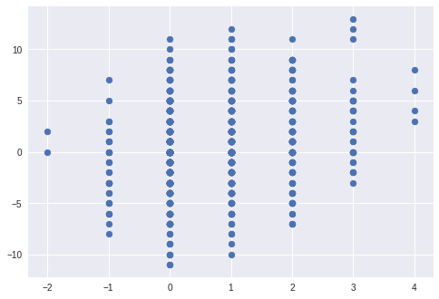

```python
d=2
mu=np.array([1,1])
sigma=np.array([[1,1],[1,5]])
x=np.array([0,0])

store_x = monte_carlo(x,mu,sigma,d,1000)
np.shape(store_x)

pyplot.scatter(store_x[:,0],store_x[:,1])
```

### Problem 3.c

I didn't conclude an explict formula in 2.b therefore I don't know how to implement. Sorry.